# Can we categorise exercise performance?

Stewart, Jason

July 29, 2016

## Summary

The aim of this document is to see if we can quantify how well a participant is performing an exercise, in this study barbell lifts. This is done by analysing patterns in data from participants doing the exercise to varying degrees of success. Using modelling techniques and accelerometer data from appropriately positioned devices we can do this successfully.

## Data transformation

In order to model this data I would first like to transform the data and reduce the number of predictors and reduce the noise. To do this I have decided to use pricipal components to make new variables that capture 90% of the variance.

*Please note, all code used to create these results is in the appendix.*

The principal components needed 13 components to capture 90 percent of the variance.

## Building the model

Our target variable is a categorical one, decision trees and random forests perform well with this type of target so I have opted to use a random forest algorithm.

Feeding in these these principal component variables I will try and predict the ‘classe’ of the exercise. This ranges from A to E where each was a barbell curl performed to a different degree of accuracy.

```r
random_forest$finalModel
```

```
##
## Call:
##  randomForest(x = x, y = y, mtry = param$mtry)
##                Type of random forest: classification
##                      Number of trees: 500
## No. of variables tried at each split: 2
##
##         OOB estimate of  error rate: 39.66%
## Confusion matrix:
##    A  B  C  D  E class.error
## A 75 14  7 12  1   0.3119266
## B 13 42 10  6  8   0.4683544
## C 13  3 45  6  3   0.3571429
## D  8  8  7 37  9   0.4637681
## E  7 15  3  8 46   0.4177215
```

To enhance the model I have created a generalised boosting model and combined it with the original model. I have done this by generating the results from both and creating a new model from these results.

Looking at the final results table we can see the combination model fits the data perfectly, however there is a risk of overfitting.

```r
combo_mod$finalModel
```

```
##
## Call:
##  randomForest(x = x, y = y, mtry = param$mtry)
##                Type of random forest: classification
##                      Number of trees: 500
## No. of variables tried at each split: 2
##
##         OOB estimate of  error rate: 0%
## Confusion matrix:
##     A  B  C  D  E class.error
## A 109  0  0  0  0           0
## B   0 79  0  0  0           0
## C   0  0 70  0  0           0
## D   0  0  0 69  0           0
## E   0  0  0  0 79           0
```

To assess this I shal perform some validation:

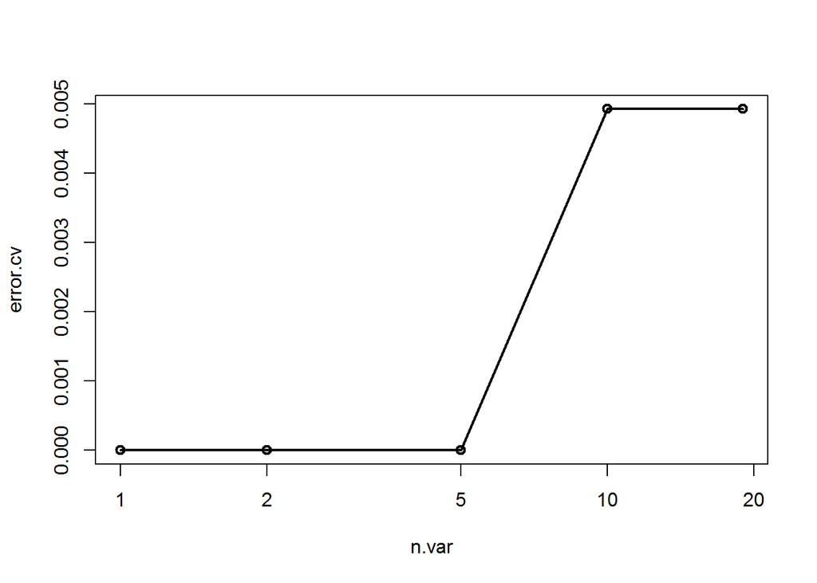

```r
with(CrossValid, plot(n.var, error.cv, log="x", type="o", lwd=2))
```

Over 20 folds the error margains remain very low.

## Test results

I have been provided a 20 case test set, using this I will now assess my models predictability. To do this I have created the same principal components and then ran all 3 model processes over the data.

## Conclusion

I can thus conclude that it is possible to predict how good an exercise has been performed, though my model was slightly overfitted.

# Appendix

```r
#Download data

pml_training <- read.csv("pml-training.csv", header=TRUE)
pml_testing <- read.csv("pml-testing.csv",header=TRUE)


#Clean data

library(e1071)
library(caret)
library(AppliedPredictiveModeling)
set.seed(12345)

#Take the records we are interested in.

pml_train2 <- pml_training[pml_training$new_window == 'yes',]

pml_train2$classe <- as.factor(pml_train2$classe)

pml_train3 <- subset(pml_train2, select= c(classe,user_name,X,raw_timestamp_part_1,raw_timestamp_part_2,cvtd_timestamp,new_window,num_window
                                            ,roll_belt,pitch_belt,yaw_belt,gyros_belt_x,gyros_belt_y,gyros_belt_z,accel_belt_x,accel_belt_y,accel_belt_z,magnet_belt_x,magnet_belt_y,magnet_belt_z
                                            ,roll_arm,pitch_arm,yaw_arm, gyros_arm_x,gyros_arm_y,gyros_arm_z,accel_arm_x,accel_arm_y,accel_arm_z,magnet_arm_x,magnet_arm_y,magnet_arm_z
                                            , roll_dumbbell,pitch_dumbbell,yaw_dumbbell, gyros_dumbbell_x,gyros_dumbbell_y,gyros_dumbbell_z,accel_dumbbell_x,accel_dumbbell_y,accel_dumbbell_z,magnet_dumbbell_x,magnet_dumbbell_y,magnet_dumbbell_z
                                            , roll_forearm,pitch_forearm,yaw_forearm, gyros_forearm_x,gyros_forearm_y,gyros_forearm_z,accel_forearm_x,accel_forearm_y,accel_forearm_z,magnet_forearm_x,magnet_forearm_y,magnet_forearm_z
)
)

pml_train4 <- pml_train3[,-c(2:8)]

#Create principle components
PCA_Base <- subset(pml_train4, select= -c(classe))
PCA <- preProcess(PCA_Base,method="pca",thresh = 0.9)

trainingPCA <- predict(PCA,pml_train4)


#Create models
random_forest <- train(classe ~ . ,method="rf", data=trainingPCA)
print(random_forest)
random_forest$finalModel

#There is an error rate of 29.31% in the train set.
#To increase the accuracy of the random forest I will add a gradient boosting model and combine them.

gbm_mod <- train(classe~.,method="gbm",data=trainingPCA)

rf_predict <- predict(random_forest,trainingPCA)
gbm_predict <- predict(gbm_mod,trainingPCA)

#Combine models

combo_data <- data.frame(rf_predict,gbm_predict, classe=trainingPCA$classe)
combo_mod <- train(classe~., method="rf", data=combo_data)

print(combo_mod)
combo_mod$finalModel
varImp(combo_mod)

#The gmb model is more important and contributing the most to the combination

combo_predict <- predict(combo_mod,combo_data)
combo_data2 <- data.frame(combo_data,combo_predict)

#Cross Validate
CrossValid <- rfcv(trainingPCA, combo_predict, cv.fold=20)
with(CrossValid, plot(n.var, error.cv, log="x", type="o", lwd=2))

#Test on test data
testing_PCA <- predict(PCA,pml_testing)
testing_PCA2 <- testing_PCA[,-c(1:111)]
#testing_PCA2 <- pml_testing
rf_predict <- predict(random_forest,testing_PCA2)
gbm_predict <- predict(gbm_mod,testing_PCA2)

combo_data_test <- data.frame(rf_predict,gbm_predict)

test_restults <- predict(combo_mod,combo_data_test)
```